# Project_survival_dop

### Reading data and EDA analysis

```r
data <- read.csv('https://stats.idre.ucla.edu/stat/data/binary.csv')
str(data)
```

```
## 'data.frame':    400 obs. of  4 variables:
##  $ admit: int  0 1 1 1 0 1 1 0 1 0 ...
##  $ gre  : int  380 660 800 640 520 760 560 400 540 700 ...
##  $ gpa  : num  3.61 3.67 4 3.19 2.93 3 2.98 3.08 3.39 3.92 ...
##  $ rank : int  3 3 1 4 4 2 1 2 3 2 ...
```

Dataset description: A researcher is interested in how variables, such as GRE (Graduate Record Exam scores), GPA (grade point average) and prestige of the undergraduate institution, effect admission into graduate school. The response variable, admit/don’t admit, is a binary variable.

```r
head(data)
```

```
##   admit gre  gpa rank
## 1     0 380 3.61    3
## 2     1 660 3.67    3
## 3     1 800 4.00    1
## 4     1 640 3.19    4
## 5     0 520 2.93    4
## 6     1 760 3.00    2
```

Let’s check NA values:

```r
colSums(is.na(data))
```

```
## admit   gre   gpa  rank
##     0     0     0     0
```

There are no NA values.

Let’s check outliers (Picture 1):

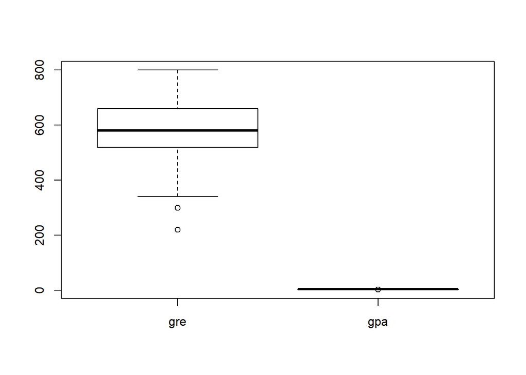

```r
boxplot(data[,2:3])
```

*Picture 1* Boxplot of gre and gpa variabilities.

There are three outliers, but I don’t want to delete them.

Rename “0” and “1” in admit variabeles to “no” and “yes”. Also let’s transform rank in factor format.

```r
data$admit <- as.factor(data$admit)
levels(data$admit) <- c("no", "yes")
data$rank <- as.factor(data$rank)
str(data)
```

```
## 'data.frame':    400 obs. of  4 variables:
##  $ admit: Factor w/ 2 levels "no","yes": 1 2 2 2 1 2 2 1 2 1 ...
##  $ gre  : int  380 660 800 640 520 760 560 400 540 700 ...
##  $ gpa  : num  3.61 3.67 4 3.19 2.93 3 2.98 3.08 3.39 3.92 ...
##  $ rank : Factor w/ 4 levels "1","2","3","4": 3 3 1 4 4 2 1 2 3 2 ...
```

Histogram of “gre” variables (Picture 2).

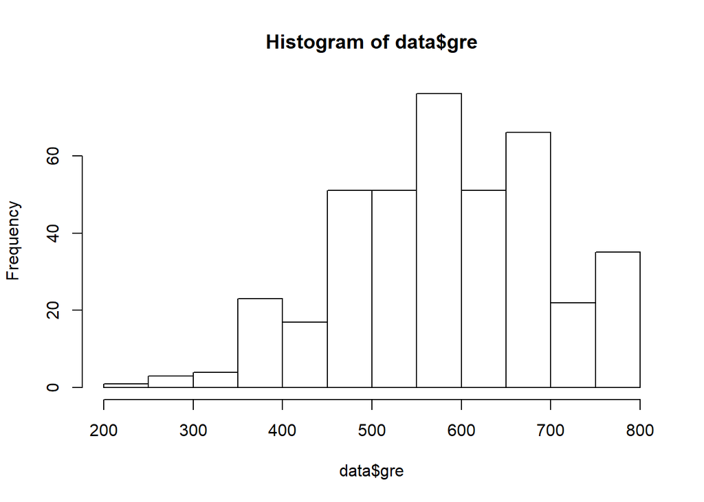

```r
hist(data$gre)
```

*Picture 2* Histogram of gre variables

Histogram of “gpa” variables (Picture 3).

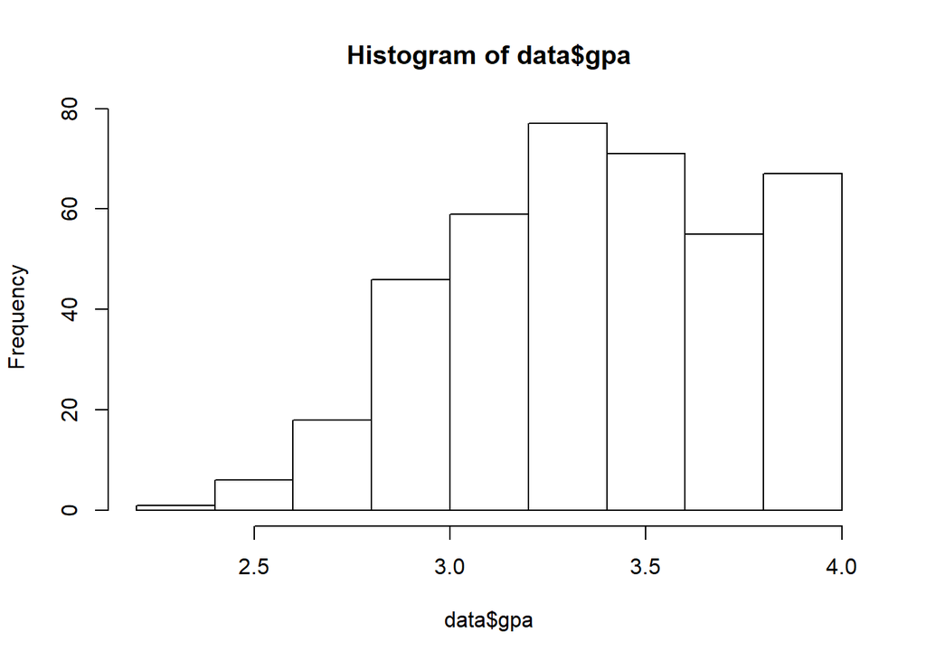

```r
hist(data$gpa)
```

*Picture 3* Histogram of gpa variables

### Log regression

Let’s see at the interaction of all variables (Picture 4).

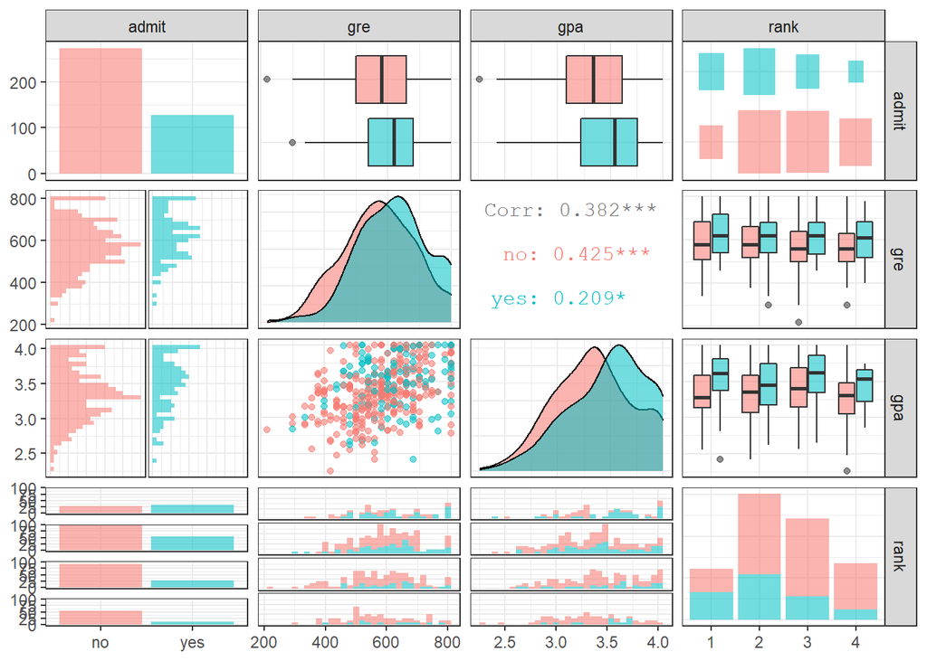

```r
ggpairs(data ,aes(color = data$admit, alpha = 0.5), upper = list(continuous = wrap("cor", method = "spearman", size = 4)))
```

*Picture 4* Interaction of all variables.

Logistic model:

```r
mod <- glm(admit ~ gre + gpa + rank, family = binomial(link = 'logit'), data = data)
summary(mod)
```

```
##
## Call:
## glm(formula = admit ~ gre + gpa + rank, family = binomial(link = "logit"),
##     data = data)
##
## Deviance Residuals:
##     Min       1Q   Median       3Q      Max
## -1.6268  -0.8662  -0.6388   1.1490   2.0790
##
## Coefficients:
##              Estimate Std. Error z value Pr(>|z|)
## (Intercept) -3.989979   1.139951  -3.500 0.000465 ***
## gre          0.002264   0.001094   2.070 0.038465 *
## gpa          0.804038   0.331819   2.423 0.015388 *
## rank2       -0.675443   0.316490  -2.134 0.032829 *
## rank3       -1.340204   0.345306  -3.881 0.000104 ***
## rank4       -1.551464   0.417832  -3.713 0.000205 ***
## ---
## Signif. codes:  0 '***' 0.001 '**' 0.01 '*' 0.05 '.' 0.1 ' ' 1
##
## (Dispersion parameter for binomial family taken to be 1)
##
##     Null deviance: 499.98  on 399  degrees of freedom
## Residual deviance: 458.52  on 394  degrees of freedom
## AIC: 470.52
##
## Number of Fisher Scoring iterations: 4
```

```r
Anova(mod)
```

```
## Analysis of Deviance Table (Type II tests)
##
## Response: admit
##      LR Chisq Df Pr(>Chisq)
## gre    4.3578  1    0.03684 *
## gpa    6.0143  1    0.01419 *
## rank  21.8265  3  7.088e-05 ***
## ---
## Signif. codes:  0 '***' 0.001 '**' 0.01 '*' 0.05 '.' 0.1 ' ' 1
```

All of variables are significant.

Find optimal model.

```r
drop1(mod, test = "Chi")
```

```
## Single term deletions
##
## Model:
## admit ~ gre + gpa + rank
##        Df Deviance    AIC     LRT  Pr(>Chi)
## <none>      458.52 470.52
## gre     1   462.88 472.88  4.3578   0.03684 *
## gpa     1   464.53 474.53  6.0143   0.01419 *
## rank    3   480.34 486.34 21.8265 7.088e-05 ***
## ---
## Signif. codes:  0 '***' 0.001 '**' 0.01 '*' 0.05 '.' 0.1 ' ' 1
```

There is no reason to find optimal model. It is already optimal.

Model diagnostics:

-Linearity check (Picture 5) It’s can be checked using residual graph

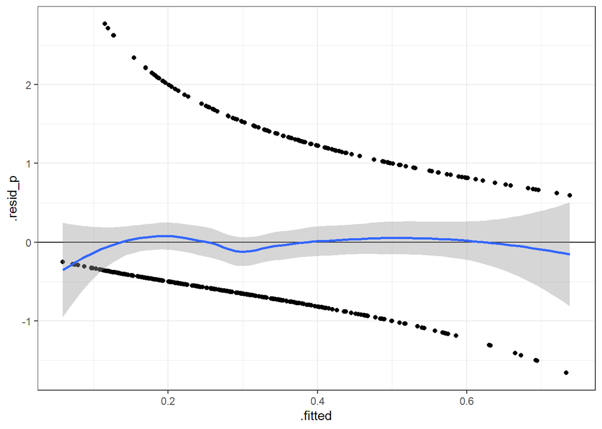

```r
mod_diag <- data.frame(.fitted = fitted(mod, type = 'response'),
                        .resid_p = resid(mod, type = 'pearson'))

ggplot(mod_diag, aes(y = .resid_p, x = .fitted)) +
  geom_point() +
  theme_bw() +
  geom_hline(yintercept = 0) +
  geom_smooth(method = 'loess')
```

*Picture 5* Residual graph.

Linearity is not broken.

-Check superdispersion

```r
overdisp_fun <- function(model) {
  rdf <- df.residual(model)
  if (any(class(model) == 'negbin')) rdf <- rdf - 1
  rp <- residuals(model,type='pearson')
  Pearson.chisq <- sum(rp^2)
  prat <- Pearson.chisq/rdf
  pval <- pchisq(Pearson.chisq, df=rdf, lower.tail=FALSE)
  c(chisq=Pearson.chisq,ratio=prat,rdf=rdf,p=pval)
}

overdisp_fun(mod)
```

```
##       chisq       ratio         rdf           p
## 397.4901989   1.0088584 394.0000000   0.4412888
```

This model has no superdispersion.

-Check multicollinearity

```r
vif(mod) > 2
```

```
##       GVIF    Df GVIF^(1/(2*Df))
## gre  FALSE FALSE           FALSE
## gpa  FALSE FALSE           FALSE
## rank FALSE  TRUE           FALSE
```

There is no multicollinerity.

### Model prediction and visualization

Create an artificial dataset.

```r
new_data <- data %>% group_by(rank) %>% do(data.frame(gpa = seq(from = min(.$gpa), to = max(.$gpa), length.out = 100), gre = mean(.$gre)))

X <- model.matrix(~ gre + gpa + rank, data = new_data)
b <- coef(mod)

new_data$fit_eta <- X %*% b
new_data$se_eta <- sqrt(diag(X %*% vcov(mod) %*% t(X)))

logit_back <- function(x) exp(x)/(1 + exp(x))

new_data$fit_pi <- logit_back(new_data$fit_eta)

new_data$lwr_pi <- logit_back(new_data$fit_eta - 2 * new_data$se_eta)
new_data$upr_pi <- logit_back(new_data$fit_eta + 2 * new_data$se_eta)

head(new_data, 2)
```

```
## # A tibble: 2 x 8
## # Groups:   rank [1]
##   rank    gpa   gre fit_eta[,1] se_eta fit_pi[,1] lwr_pi[,1] upr_pi[,1]
##   <fct> <dbl> <dbl>       <dbl>  <dbl>      <dbl>      <dbl>      <dbl>
## 1 1      2.42  612.      -0.659  0.432      0.341      0.179      0.551
## 2 1      2.44  612.      -0.646  0.427      0.344      0.182      0.552
```

Prediction graph in connection scale function (Picture 6):

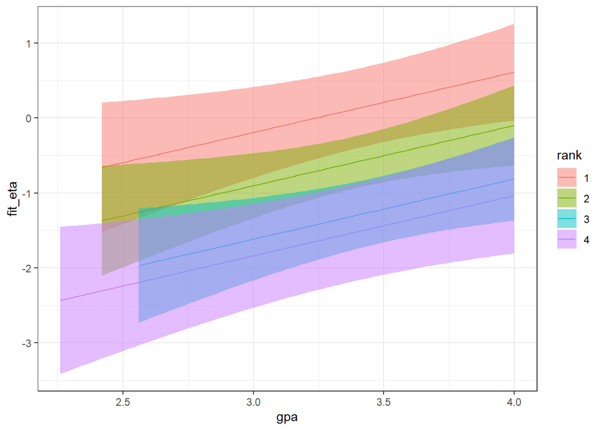

```r
ggplot(new_data, aes(x = gpa, y = fit_eta, fill = rank))  +
  geom_line(aes(color = rank)) +
  geom_ribbon(aes(ymin = fit_eta - 2 * se_eta, ymax = fit_eta + 2 * se_eta), alpha = 0.5)+
  theme_bw()
```

*Picture 6* “gpa” prediction

Prediction graph at response scale (Picture 7):

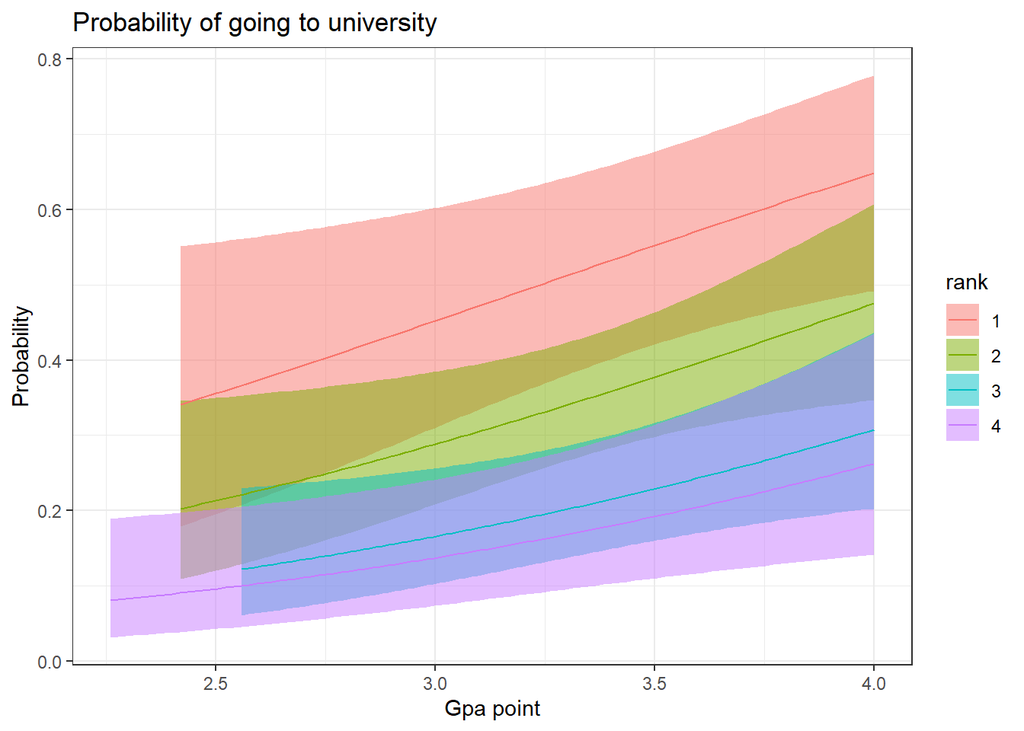

```r
ggplot(new_data, aes(x = gpa, y = fit_pi, fill = rank)) +
  geom_ribbon(aes(ymin = lwr_pi, ymax = upr_pi), alpha = 0.5) +
  geom_line(aes(color = rank)) +
  labs(y='Probability', x = 'Gpa point', title = 'Probability of going to university') +
  theme_bw()
```

### ROC curve

ROC curve (Picture 7):

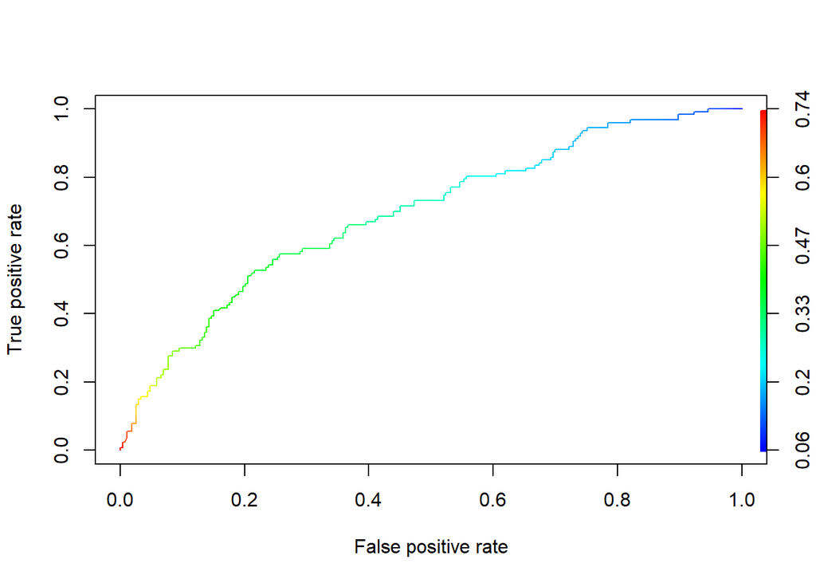

```r
data$responce <- predict(mod, type = 'response')
prediction <- prediction(data$responce, data$admit)
perf <- performance(prediction, "tpr", "fpr")
plot(perf, colorize=T)
```

*Picture 7* ROC curve

AUC:

```r
auc.tmp <- performance(prediction,"auc")
auc <- as.numeric(auc.tmp@y.values)
print(auc)
```

```
## [1] 0.6928413
```

Optimal cutoff :

```r
opt.cut = function(perf, prediction){
    cut.ind = mapply(FUN=function(x, y, p){
        d = (x - 0)^2 + (y-1)^2
        ind = which(d == min(d))
        c(sensitivity = y[[ind]], specificity = 1-x[[ind]],
            cutoff = p[[ind]])
    }, perf@x.values, perf@y.values, prediction@cutoffs)
}
print(opt.cut(perf, prediction))
```

```
##                  [,1]
## sensitivity 0.5748031
## specificity 0.7435897
## cutoff      0.3539422
```

Confusion matrix:

```r
#install.packages('e1071', dependencies=TRUE)
data$responce2 <- ifelse(data$responce >= 0.3539422, 'yes', 'no')
data$responce2 <- as.factor(data$responce2)
confusionMatrix(data$responce2, data$admit)
```

```
## Confusion Matrix and Statistics
##
##           Reference
## Prediction  no yes
##        no  203  55
##        yes  70  72
##
##                Accuracy : 0.6875
##                  95% CI : (0.6396, 0.7326)
##     No Information Rate : 0.6825
##     P-Value [Acc > NIR] : 0.4385
##
##                   Kappa : 0.301
##
##  Mcnemar's Test P-Value : 0.2105
##
##             Sensitivity : 0.7436
##             Specificity : 0.5669
##          Pos Pred Value : 0.7868
##          Neg Pred Value : 0.5070
##              Prevalence : 0.6825
##          Detection Rate : 0.5075
##    Detection Prevalence : 0.6450
##       Balanced Accuracy : 0.6553
##
##        'Positive' Class : no
##
```

Chart of successful prediction (Picture 8):

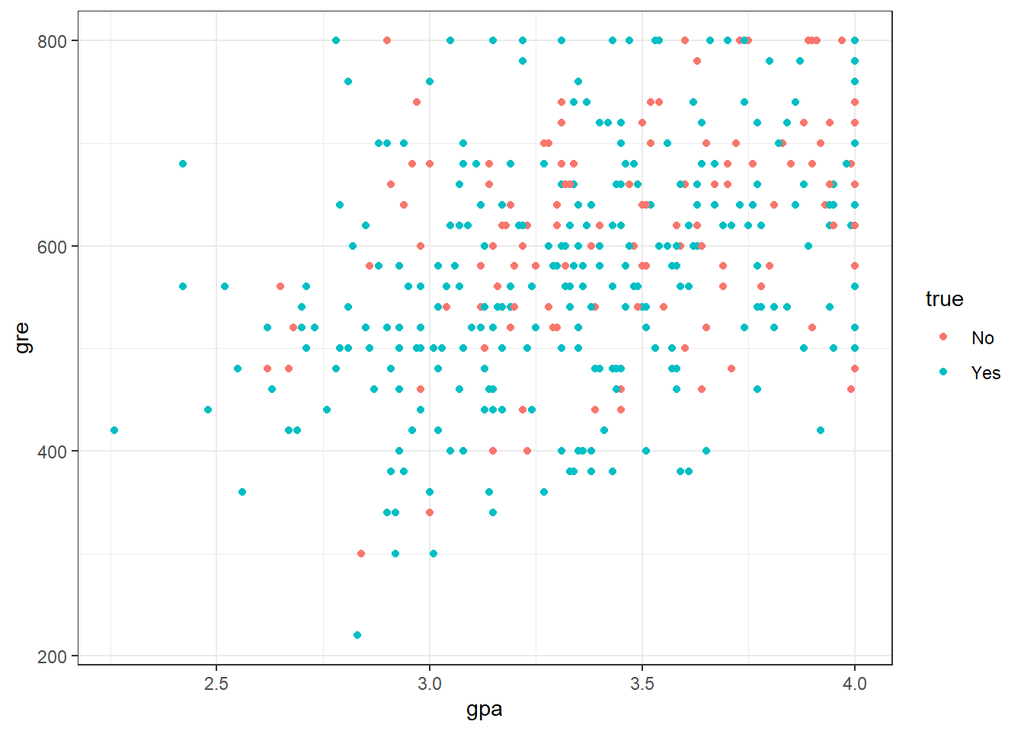

```r
data$true <- ifelse(data$admit == data$responce2, "Yes", "No")

ggplot(data, aes(y = gre, x = gpa)) +
  geom_point(aes(color = true))
```

*Picture 8* Chart of successful predictions.

As we can see from the chart above, there are more green dots than red ones.